# DS-PATH R Data Visualization Workshop

# Pattern detection - `geom_smooth()`

In data analysis, uncovering patterns and relationships within data sets is crucial for understanding underlying trends and making informed decisions. Building off the scatter plot we use the `geom_smooth()` to help explore patterns.

We use `grid.arrange()` in the `gridExtra` library to help us rearrange the plots. You may need to install it if you do not have the package already.

```r
# install.packages("gridExtra")
library(gridExtra)
```

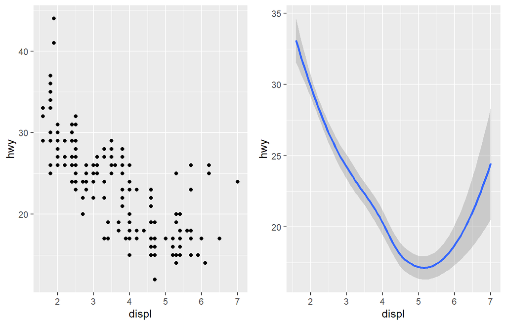

```r
# gives scatter plot
plot1 <- ggplot(data = mpg) +
  geom_point(mapping = aes(x = displ, y = hwy))
# gives trend (without points)
plot2 <- ggplot(data = mpg) +
  geom_smooth(mapping = aes(x = displ, y = hwy))
grid.arrange(plot1, plot2, ncol=2)
## `geom_smooth()` using method = 'loess' and formula = 'y ~ x'
```

### Multiple geoms/layers in the same plot

We can then combine the two points together and visualize it that way.

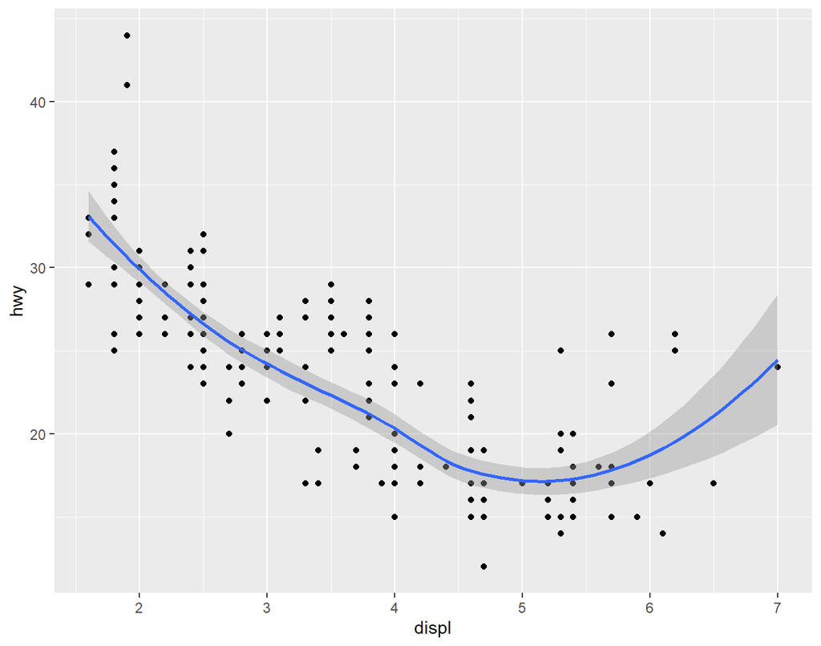

```r
ggplot(data = mpg) +
  geom_point(mapping = aes(x = displ, y = hwy)) +
  geom_smooth(mapping = aes(x = displ, y = hwy))
## `geom_smooth()` using method = 'loess' and formula = 'y ~ x'
```

### Aesthetics options for `geom_smooth()`

`geom_smooth` understands the following aesthetics

- **x (required!)**
- **y (required!)**
- alpha
- colour
- fill
- group
- linetype (line specific)
- size
- weight
- ymax
- ymin

Learn more about these aesthetics in `vignette("ggplot2-specs")`.

```r
vignette("ggplot2-specs")
```

### Aesthetic mappings for `geom_smooth()` - `group`

- By default, `geom_smooth()` uses a single geometric object to display the entire data.
- You can set the `group` aesthetic to a categorical variable to draw multiple objects.

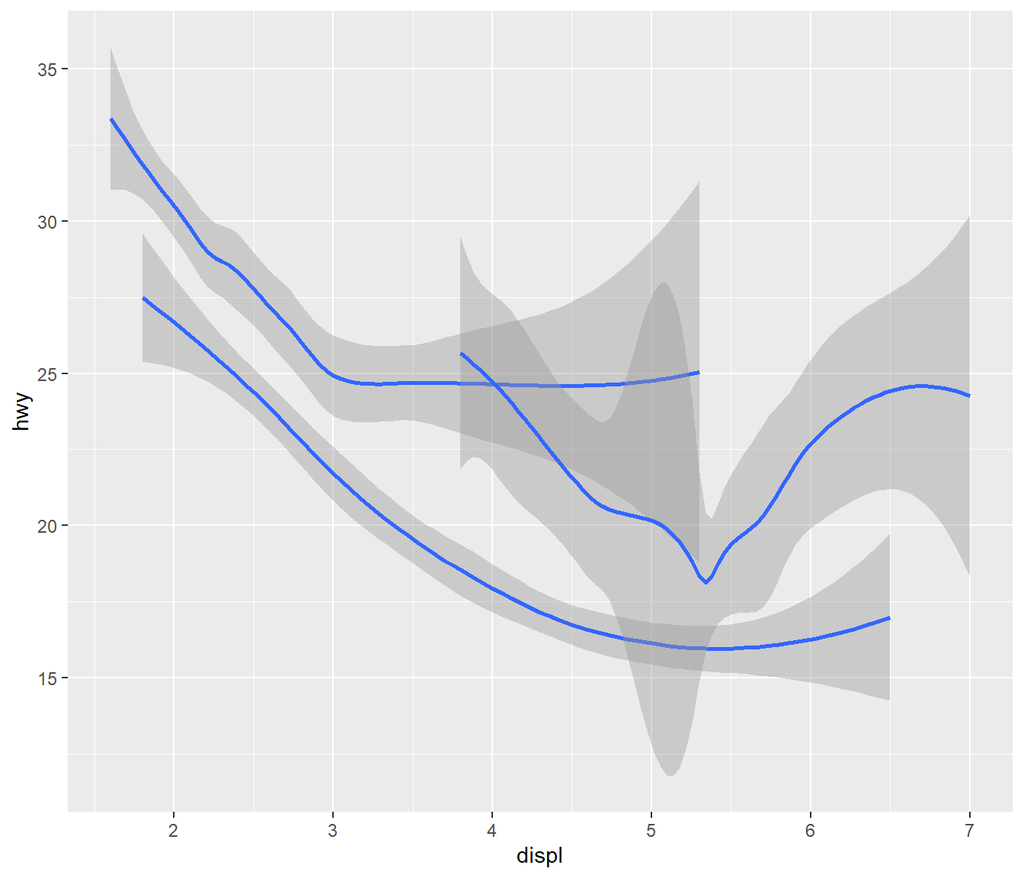

```r
ggplot(data = mpg) +
  geom_smooth(mapping = aes(x = displ, y = hwy, group = drv))
## `geom_smooth()` using method = 'loess' and formula = 'y ~ x'
```

### Aesthetic mappings for `geom_smooth()` - `linetype`

- In practice, `ggplot2` will automatically group the data whenever you map an aesthetic (for example, `linetype`) to a discrete variable.

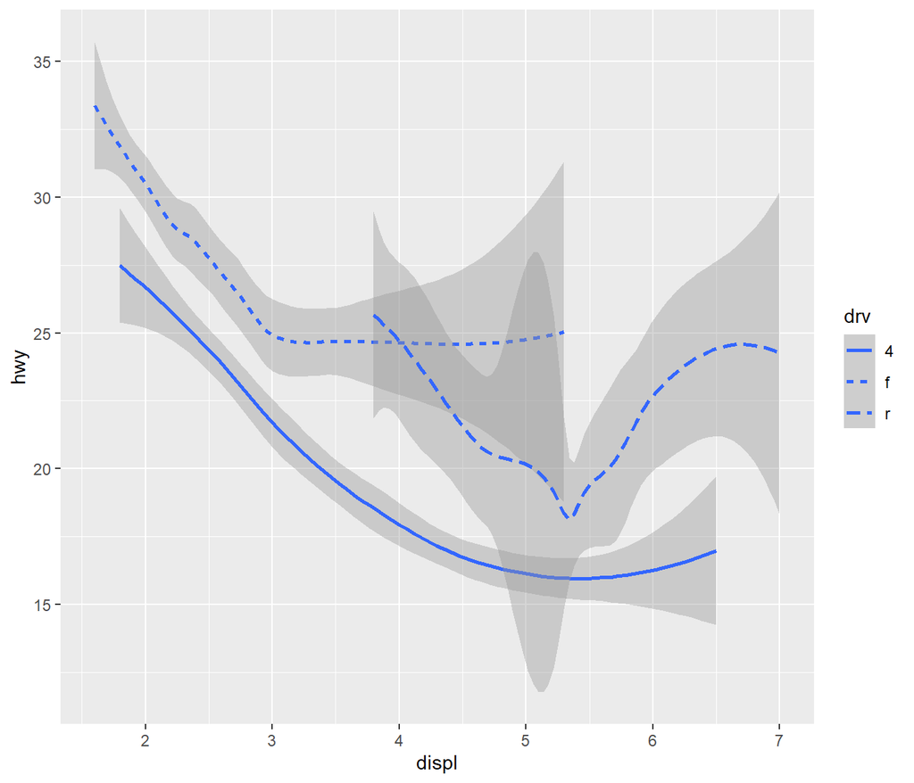

```r
ggplot(data = mpg) +
  geom_smooth(mapping = aes(x = displ, y = hwy, linetype = drv))
## `geom_smooth()` using method = 'loess' and formula = 'y ~ x'
```

### Aesthetic mappings for both `geom_point()` & `geom_smooth()`

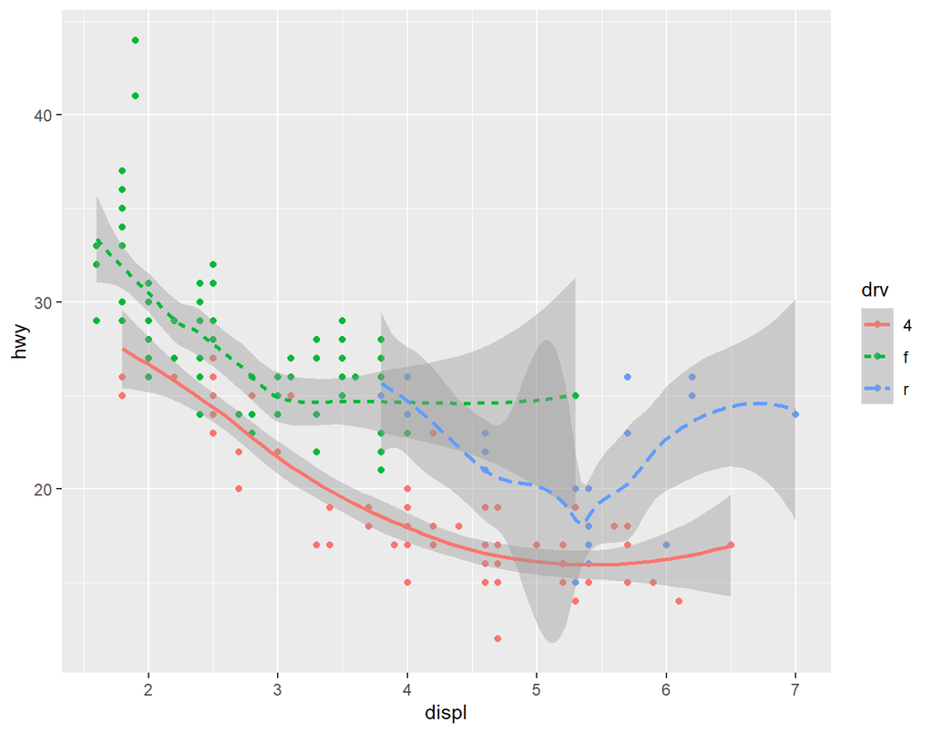

```r
ggplot(data = mpg) +
  geom_point(mapping = aes(x = displ, y = hwy, col = drv)) +
  geom_smooth(mapping = aes(x = displ, y = hwy, col = drv, linetype = drv))
## `geom_smooth()` using method = 'loess' and formula = 'y ~ x'
```

### Global and local aesthetic mappings

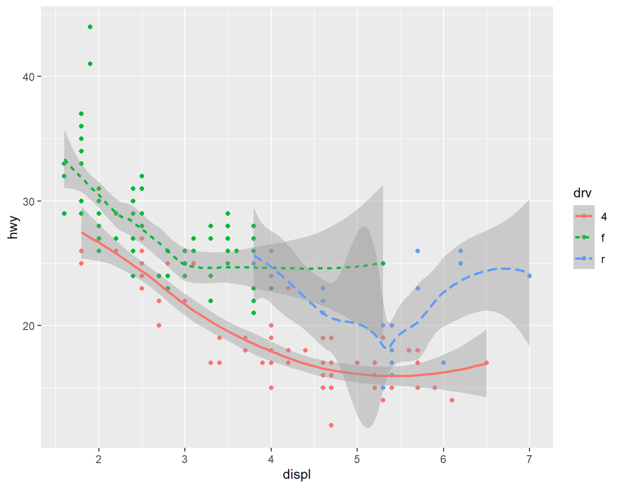

```r
ggplot(data = mpg,
       mapping = aes(x = displ, y = hwy, col = drv)) + # global mapping
  geom_point() +
  geom_smooth(mapping = aes(linetype = drv)) # local mapping for the layer
## `geom_smooth()` using method = 'loess' and formula = 'y ~ x'
```

### `geom_smooth()` - other arguments

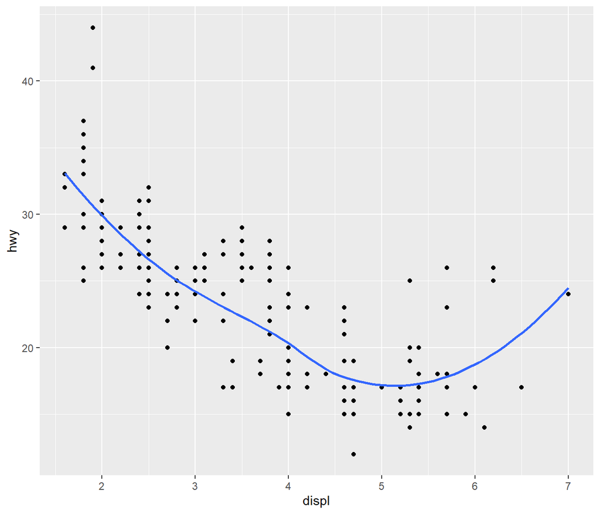

```r
ggplot(data = mpg, mapping = aes(x = displ, y = hwy)) +
  geom_point() +
  geom_smooth(se = FALSE) # remove interval
## `geom_smooth()` using method = 'loess' and formula = 'y ~ x'
```

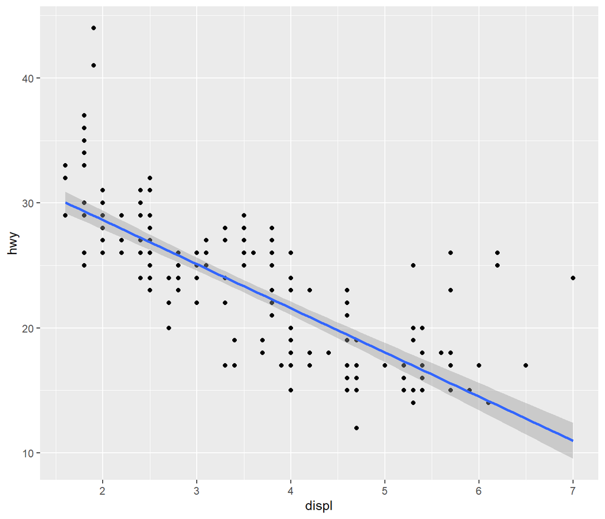

```r
ggplot(data = mpg, mapping = aes(x = displ, y = hwy)) +
  geom_point() +
  geom_smooth(method = "lm") # change method of prediction
## `geom_smooth()` using formula = 'y ~ x'
```

### DEMO: `geom_smooth()`

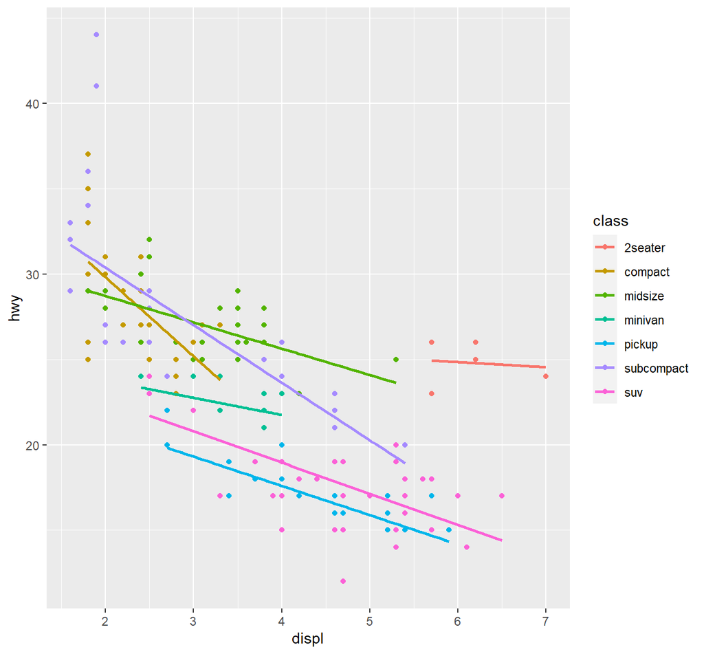

### **Exercise**

Write your own ggplot code to reproduce the following four plots. When generating these plots, focus on the aesthetic mappings in the reference plot. It is OK if the text font size or point size in your plot look different from the reference plot.

1. Reproduce this plot:

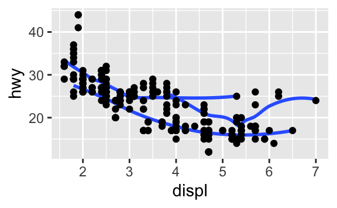

```r
# insert code here
```

2. Reproduce this plot:

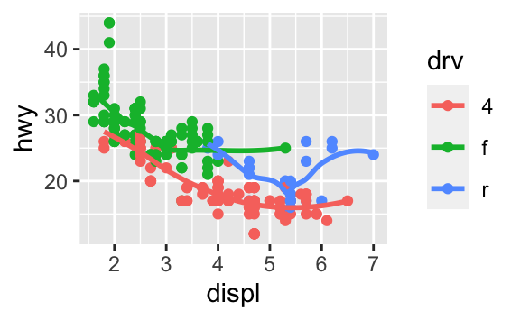

```r
# insert code here
```

3. Reproduce this plot:

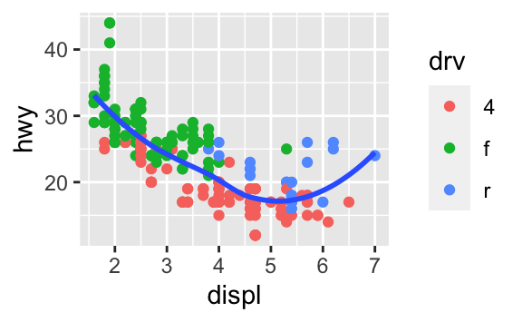

```r
# insert code here
```

4. Reproduce this plot:

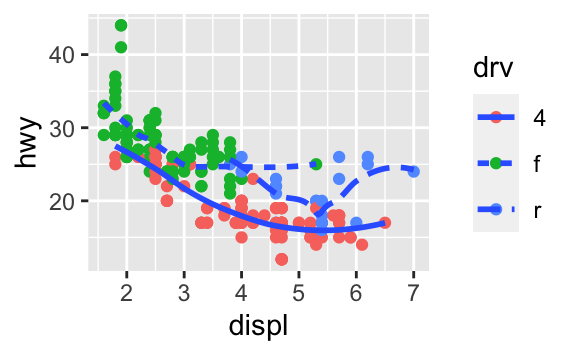

```r
# insert code here
```

# Line Plots

```r
ggplot(data = df, aes(x = x_var, y = y_var)) +
  geom_line()
```

# Histogram!

Note: histograms and bar plots are NOT the same. Although sometimes used interchangeably, most statisticians will say they are note. The key distinction is what the purpose is for. Generally,

- Histograms are for visualization of the distribution of *numerical* variables
- Bar plots are used for visualization of *categorical* variables.

Similar to the format for scatter plots and line plots, to create a histogram, we start with the `ggplot(data = data_name) +` call and then add the `geom_histogram(mapping = aes(...))` call.

```r
ggplot(data = your_data) +
  geom_histogram(mapping = aes(x = your_variable))
```

Visualizing the histogram

```r
ggplot(data = mpg) +
  geom_histogram(mapping = aes(x = hwy), bins = 30, fill = "skyblue", color = "black") +
  labs(title = "Histogram of Highway MPG", x = "Highway MPG", y = "Frequency")
```

[output not shown]

# The `diamonds` data frame

We explore another dataset in `ggplot2` library: `diamonds`. This data set contains the prices and other attributes of almost 54,000 diamonds. To view more in detail, type `?diamonds` in the console.

```r
dim(diamonds)  # dimension of the table
```

```
## [1] 53940    10
```

```r
#names(diamonds)  # list the variables in diamonds
#str(diamonds)  # list the structures in diamonds
glimpse(diamonds)  # get a glimpse of the diamonds data
```

```
## Rows: 53,940
## Columns: 10
## $ carat   <dbl> 0.23, 0.21, 0.23, 0.29, 0.31, 0.24, 0.24, 0.26, 0.22, 0.23, 0.…
## $ cut     <ord> Ideal, Premium, Good, Premium, Good, Very Good, Very Good, Ver…
## $ color   <ord> E, E, E, I, J, J, I, H, E, H, J, J, F, J, E, E, I, J, J, J, I,…
## $ clarity <ord> SI2, SI1, VS1, VS2, SI2, VVS2, VVS1, SI1, VS2, VS1, SI1, VS1, …
## $ depth   <dbl> 61.5, 59.8, 56.9, 62.4, 63.3, 62.8, 62.3, 61.9, 65.1, 59.4, 64…
## $ table   <dbl> 55, 61, 65, 58, 58, 57, 57, 55, 61, 61, 55, 56, 61, 54, 62, 58…
## $ price   <int> 326, 326, 327, 334, 335, 336, 336, 337, 337, 338, 339, 340, 34…
## $ x       <dbl> 3.95, 3.89, 4.05, 4.20, 4.34, 3.94, 3.95, 4.07, 3.87, 4.00, 4.…
## $ y       <dbl> 3.98, 3.84, 4.07, 4.23, 4.35, 3.96, 3.98, 4.11, 3.78, 4.05, 4.…
## $ z       <dbl> 2.43, 2.31, 2.31, 2.63, 2.75, 2.48, 2.47, 2.53, 2.49, 2.39, 2.…
```

Make sure to note which variables are categorical or not!

# Bar plot for categorical variable

### `geom_bar()` makes bar plot (histogram) for discrete variable

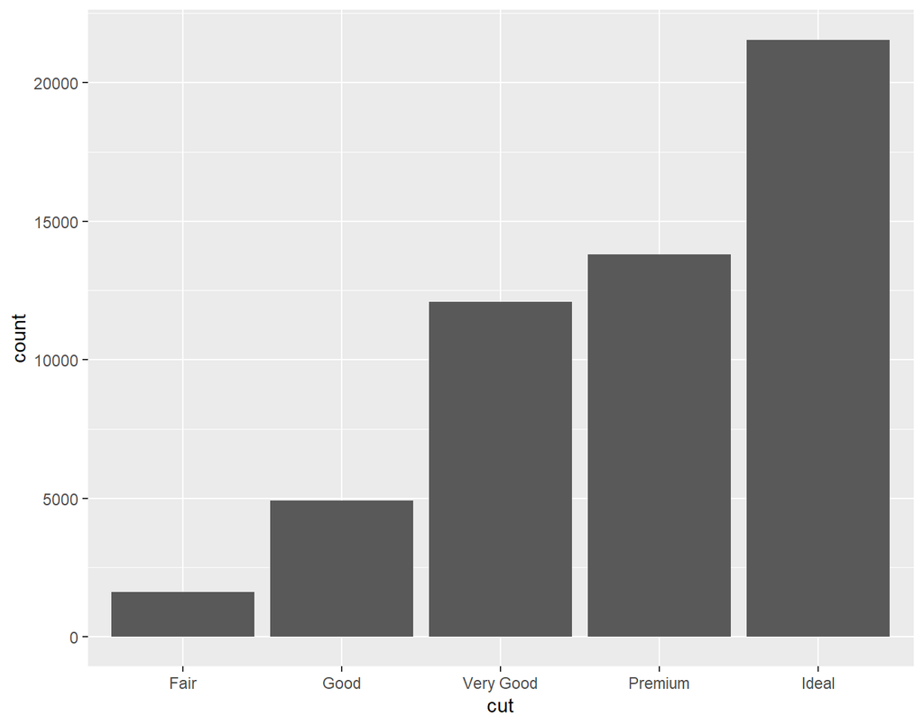

```r
ggplot(data = diamonds) +
  geom_bar(mapping = aes(x = cut))
```

### Make a proportion bar chart (relative frequency histogram)

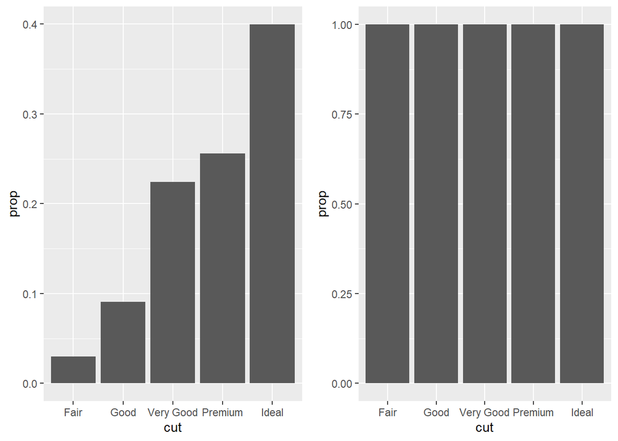

```r
plot1 <- ggplot(data = diamonds) +
  geom_bar(mapping = aes(x = cut, y = ..prop.., group = 1))
plot2 <- ggplot(data = diamonds) +
  geom_bar(mapping = aes(x = cut, y = ..prop..))
grid.arrange(plot1, plot2, ncol=2)
```